# Machine Learning in Python - Project 1

Due Friday, March 6th by 5 pm.

## 1. Setup

### 1.1 Libraries

```python
# Add any additional libraries or submodules below

# Display plots inline
%matplotlib inline

# Data libraries
import pandas as pd
import numpy as np

# Plotting libraries
import matplotlib.pyplot as plt
import seaborn as sns

# Plotting defaults
plt.rcParams['figure.figsize'] = (8,5)
plt.rcParams['figure.dpi'] = 80

# sklearn modules
import sklearn
from sklearn.decomposition import PCA
from sklearn.preprocessing import StandardScaler
from sklearn.kernel_ridge import KernelRidge
from sklearn.metrics import mean_squared_error
from sklearn.model_selection import GridSearchCV
from sklearn.metrics.pairwise import pairwise_kernels
from scipy import stats
```

### 1.2 Data

```python
sales = pd.read_csv("sales.csv")
sales_test = pd.read_csv("sales_test.csv")
```

## 2. Exploratory Data Analysis and Preprocessing

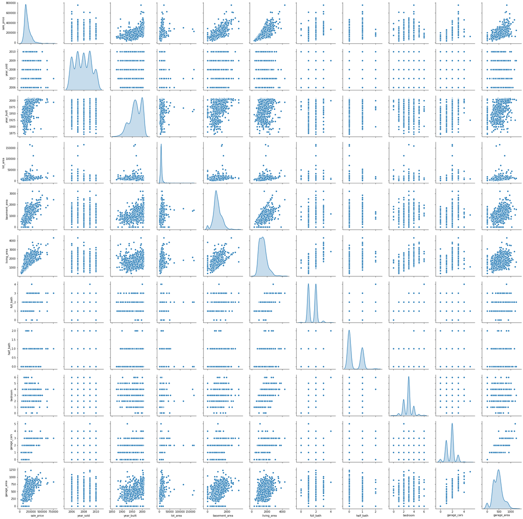

```python
#pairwise plot
sns.pairplot(sales, diag_kind='kde')
```

```python
def plot_logscale(X, field):
    '''
    This function will plot the distribution of original data and log data.
    '''

    fig, ax = plt.subplots(1, 2, figsize = [17, 4])
    plt.subplot(121)
    sns.kdeplot(X[field], label = field)
    plt.title('Kdeplot of {}'.format(field))
    plt.xlabel(field)

    plt.subplot(122)
    sns.kdeplot(np.log(X[field]), label = 'log {}'.format(field))
    plt.title('Kdeplot of Log {}'.format(field))
    plt.xlabel('Log {}'.format(field))
```

```python
def plot_logpoint(X, field):
    '''
    This function will plot the points between input field and sale_price compare
    to log scale
    '''

    fig, ax = plt.subplots(1, 2, figsize = [17, 4])
    plt.subplot(121)
    sns.scatterplot(X[field], X.sale_price)
    plt.title('Scatterplot of {}'.format(field))
    plt.xlabel(field)

    plt.subplot(122)
    sns.scatterplot(np.log(X[field]), np.log(X.sale_price), label = 'log sale price')
    plt.title('Scatterplot of Log {}'.format(field))
    plt.xlabel('Log {}'.format(field))
```

```python
def Normaltest(X):

    k2, p = stats.normaltest(X)
    alpha = 0.05

    if p < alpha:
        print('it can be rejected that the input is normal distribution')
    else:
        print('can not reject the input is normal distirbution')

    return('p value is: {:.3e}'.format(p))
```

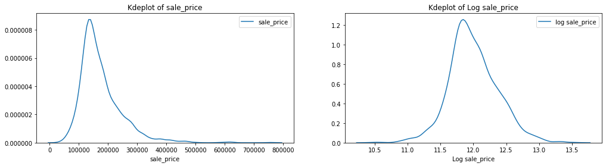

```python
plot_logscale(sales, 'sale_price')
```

Secondly, from the pairplot in the begining, we can find in the row of `lot_area`, there is some outliers and the distribution is also right skewed. So I use log scale again to reduce the distance between outliers and normal points. It also can make it symmetric. These two reasons make it easier to predict sale price. The comparasion of scatter plot and kde plot can be seen below.

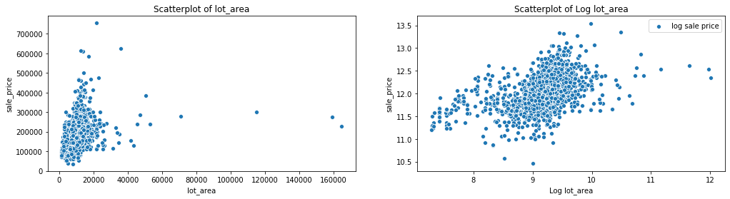

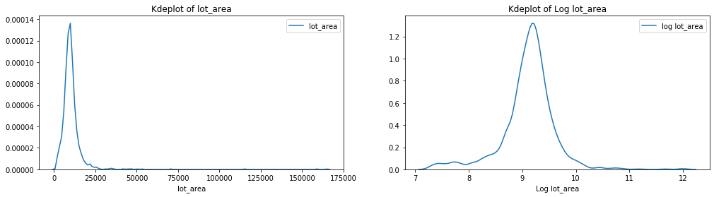

```python
plot_logpoint(sales, 'lot_area')
plot_logscale(sales, 'lot_area')
```

Then, I try to remove the outliers based on `sale_price`. I created two outlier removing methods, the one is using **3$\delta$ thery of normal distriution**. Another one is using **Inter Quartile Range**. When using **3$\delta$ theory**, it is better to check whether the sample is follow normal distribution. Below is a normal distribution test.

```python
Normaltest(np.log(sales.sale_price))
```

```
it can be rejected that the input is normal distribution
```

```
'p value is: 9.963e-10'
```

From above test, we can not use **normal distribution** to remove the outlier. So it is better to use **IQR** to remove the outliers. below is the boxplot of `sale_price`.

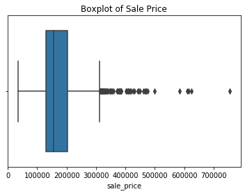

```python
sns.boxplot(sales.sale_price)
plt.title('Boxplot of Sale Price')
```

We can find there are many points outside the *maximum value(Q3 + 1.5IQR)*. However, after tried these two outlier detections, the results show that removing outlier can improve the *RMSE* of training data but it is useless for predict test data. The reason is that I have overfit the model and the outlier is not only appear in the training data but also in test data. So that I will not using outlier detection methods for this data. The results will be showed in supplemental notebook.

Then I devide the data into **numeric data** and **categorical data**. The categorical data is the string data after `dummy` process. In **numeric data**, I also devide them into **normal data** and **ordered data**. The **ordered data** is the number of rooms or garage cars. In `process` function, I also set a parameter called `only_continuous` which is used for whether scale only the numeric data or scale the whole data. When `only_continuous` is `True`, I use `StandardScale` process for **normal data** and log scale for **ordered data**, The reason is **ordered data** has smaller deviance than one and it is not good to scale it to one and scale **categorical data** make no sense and it will even make prediction worse. The standard deviation of each feature can be seen below.It should be noticed that I drop the variable `year_sold`. The reason is that it has too small deviation compare to other normal data and small correlation with sale price which will be discussed in the later part. These are all the preprocess procedures in the `process` function.

```python
np.std(sales)
```

```
sale_price       72010.437052
year_sold            1.311858
year_built          28.772073
lot_area          7777.188321
basement_area      415.581044
living_area        496.517870
full_bath            0.555254
half_bath            0.497904
bedroom              0.813268
garage_cars          0.724346
garage_area        198.746623
dtype: float64
```

The second function is `get_corr` which will return the correlation of each numeric feature before scale and plot the heatmap. The detail of the `data_analysis` class can be seen in the code.

```python
class data_analysis:
    '''
    This class has three functions. The first function is used to preprocess
    data and return the variable and label. The second function is used to
    calculate the correlation between each feature and plot in a heat map.
    The third function is used to plot the points between pc components
    and sales price.
    '''

    def __init__(self, train, test):
        self.train = train.copy()
        self.test = test.copy()
        self.x = self.train.shape[0]
        self.y = self.test.shape[0]
        self.sales = pd.concat([self.train, self.test], axis=0)

        #using train data as reference
        low = self.train.groupby(['neighborhood']).mean().sale_price.sort_values(axis=0).index[0:10]
        median = self.train.groupby(['neighborhood']).mean().sale_price.sort_values(axis=0).index[10:18]
        high = self.train.groupby(['neighborhood']).mean().sale_price.sort_values(axis=0).index[18:24]
        #perfrom to the whole data
        self.sales['nb_level'] = self.sales.neighborhood
        self.sales.nb_level.replace(low, np.repeat('nb_low', 10), inplace = True)
        self.sales.nb_level.replace(median, np.repeat('nb_median', 8), inplace = True)
        self.sales.nb_level.replace(high, np.repeat('nb_high', 6), inplace = True)

        self.sales_scale = []
        self.numeric = []
        self.all_dummy = []
        self.sales_scale_numeric = []

    def process(self, only_continuous=True):
        '''
        This function is used to process the input data
        -----------------------------------------------
        Parameters:
            data: array

            only_continuous: (boolean, default True)
                whether only sacle the sales price with continuous value.

        ----------------------------------------------
        Attributes:
            X: array
                data input

            y: array
                data output
        '''

        #from the pair plot, The sales price feild is right skewed, it is hard for
        # model to predict long tail, so using log make it symetric
        self.sales.sale_price = np.log(self.sales.sale_price)

        #from the pair plot, we find there are outliers in lot_area field, so using
        #log to reduce the distance between outliers and normal points
        self.sales.lot_area = np.log(self.sales.lot_area)

        #store all the numeric data
        self.numeric = self.sales[self.sales.describe().columns]

        #drop variable for the whole data
        drop_varibale = ['sale_price', 'year_sold']
        ordered_variable = ['full_bath', 'half_bath', 'bedroom', 'garage_cars']

        #dummy code
        self.sales_dummy = pd.get_dummies(self.sales).drop(drop_varibale, axis = 1)

        #get the column name of continuous data
        continuous_name = self.sales.describe().columns.drop(drop_varibale).drop(ordered_variable)

        #standardscale the data
        scaler = StandardScaler().fit(self.sales[0:self.x][continuous_name])
        self.sales_scale = self.sales_dummy.copy()

        #whether choose only continuous data to be scaled, transform data using
        #training parameter
        if only_continuous == True:
            self.sales_scale[continuous_name] = scaler.transform(self.sales_scale[continuous_name])
            self.sales_scale[ordered_variable] = np.log1p(self.sales_scale[ordered_variable])
        else:
            self.sales_scale[:] = scaler.transform(self.sales_dummy)

        #store the scaled numeric continuous variable
        self.sales_scale_numeric = self.sales_scale[0:self.x][continuous_name]

        y = self.sales.sale_price
        X = self.sales_scale
        train_x = X[0:self.x]
        test_x = X[self.x:self.x+self.y]
        train_y = y[0:self.x]
        test_y = y[self.x:self.x+self.y]

        return train_x, train_y, test_x, test_y

    def get_corr(self, plot=True):
        '''
        This function will return the correlation between each feature and plot
        the heatmap of corr matrix
        --------------------------------
        args:
            plot:(default True)
                whether to plot the heatmap

        note:
            in order to see the entire plot, it is better to use the matplotlib
            version of 3.1.0
        '''

        corr = np.round(self.numeric.corr(method='pearson'),4)

        if plot == True:
            fig, ax = plt.subplots(1, 1)
            sns.heatmap(np.abs(corr), annot=True, fmt=".1f", linewidths=.5)
            plt.title('The Heat Map of Correlation between each Feature')

        return corr
```

```python
obs = data_analysis(sales, sales_test)
X_train, y_train, X_test, y_test= obs.process()
```

```python
X_test
```

|  | year_built | lot_area | basement_area | living_area | full_bath | half_bath | bedroom | garage_cars | garage_area | ac_N | ... | quality_good | quality_poor | condition_average | condition_excellent | condition_fair | condition_good | condition_poor | nb_level_nb_high | nb_level_nb_low | nb_level_nb_median |
| --- | --- | --- | --- | --- | --- | --- | --- | --- | --- | --- | --- | --- | --- | --- | --- | --- | --- | --- | --- | --- | --- |
| 0 | -0.298431 | 2.550230 | 0.125790 | 0.356184 | 0.693147 | 0.000000 | 1.386294 | 1.098612 | 0.349545 | 0 | ... | 0 | 0 | 1 | 0 | 0 | 0 | 0 | 0 | 1 | 0 |
| 1 | -0.263675 | 0.514552 | -0.350651 | -1.174476 | 0.693147 | 0.000000 | 1.098612 | 0.693147 | 1.365915 | 0 | ... | 0 | 0 | 1 | 0 | 0 | 0 | 0 | 0 | 1 | 0 |
| 2 | -0.367943 | 0.929632 | 0.724951 | -0.302403 | 0.693147 | 0.693147 | 1.386294 | 0.693147 | -0.737266 | 0 | ... | 0 | 0 | 1 | 0 | 0 | 0 | 0 | 0 | 1 | 0 |
| 3 | -0.611235 | 1.524222 | -0.393964 | -1.238925 | 0.693147 | 0.000000 | 1.098612 | 1.098612 | -0.294491 | 0 | ... | 0 | 0 | 1 | 0 | 0 | 0 | 0 | 0 | 0 | 1 |
| 4 | 0.049128 | -0.142673 | -0.350651 | -1.202672 | 0.693147 | 0.000000 | 1.098612 | 1.098612 | 0.334451 | 0 | ... | 0 | 0 | 1 | 0 | 0 | 0 | 0 | 0 | 1 | 0 |
| ... | ... | ... | ... | ... | ... | ... | ... | ... | ... | ... | ... | ... | ... | ... | ... | ... | ... | ... | ... | ... | ... |
| 345 | 0.292419 | 0.738880 | 0.967984 | 0.338058 | 1.098612 | 0.000000 | 1.386294 | 1.098612 | 0.817478 | 0 | ... | 0 | 0 | 1 | 0 | 0 | 0 | 0 | 0 | 0 | 1 |
| 346 | 1.022294 | -1.406147 | 0.503574 | -0.286291 | 1.098612 | 0.000000 | 1.098612 | 1.098612 | -0.269333 | 0 | ... | 0 | 0 | 1 | 0 | 0 | 0 | 0 | 0 | 0 | 1 |
| 347 | 0.118640 | -3.651772 | -1.159158 | -0.779727 | 0.693147 | 0.693147 | 1.386294 | 0.693147 | -1.034126 | 0 | ... | 0 | 0 | 1 | 0 | 0 | 0 | 0 | 0 | 1 | 0 |
| 348 | 0.049128 | -3.113547 | -1.159158 | -0.779727 | 0.693147 | 0.693147 | 1.386294 | 0.000000 | -2.307104 | 0 | ... | 0 | 0 | 0 | 0 | 0 | 1 | 0 | 0 | 1 | 0 |
| 349 | 0.257663 | 0.684525 | 1.685053 | 0.501194 | 1.098612 | 0.000000 | 1.609438 | 1.098612 | 0.580996 | 0 | ... | 0 | 0 | 1 | 0 | 0 | 0 | 0 | 0 | 0 | 1 |

350 rows × 51 columns

|  | sale_price | year_sold | year_built | lot_area | basement_area | living_area | full_bath | half_bath | bedroom | garage_cars | garage_area |
| --- | --- | --- | --- | --- | --- | --- | --- | --- | --- | --- | --- |
| sale_price | 1.0000 | 0.0100 | 0.5773 | 0.4405 | 0.6445 | 0.7406 | 0.5805 | 0.3188 | 0.2409 | 0.6725 | 0.6622 |
| year_sold | 0.0100 | 1.0000 | 0.0190 | 0.0063 | 0.0231 | -0.0036 | 0.0236 | 0.0100 | -0.0002 | -0.0021 | 0.0014 |
| year_built | 0.5773 | 0.0190 | 1.0000 | 0.0668 | 0.3986 | 0.2143 | 0.4401 | 0.2544 | -0.0211 | 0.4995 | 0.4456 |
| lot_area | 0.4405 | 0.0063 | 0.0668 | 1.0000 | 0.3162 | 0.3702 | 0.2005 | 0.0600 | 0.2355 | 0.3132 | 0.3497 |
| basement_area | 0.6445 | 0.0231 | 0.3986 | 0.3162 | 1.0000 | 0.3889 | 0.3297 | -0.0737 | 0.0803 | 0.4300 | 0.4597 |
| living_area | 0.7406 | -0.0036 | 0.2143 | 0.3702 | 0.3889 | 1.0000 | 0.6477 | 0.4521 | 0.5568 | 0.4880 | 0.4764 |
| full_bath | 0.5805 | 0.0236 | 0.4401 | 0.2005 | 0.3297 | 0.6477 | 1.0000 | 0.1611 | 0.3882 | 0.4818 | 0.4178 |
| half_bath | 0.3188 | 0.0100 | 0.2544 | 0.0600 | -0.0737 | 0.4521 | 0.1611 | 1.0000 | 0.2891 | 0.2150 | 0.1591 |
| bedroom | 0.2409 | -0.0002 | -0.0211 | 0.2355 | 0.0803 | 0.5568 | 0.3882 | 0.2891 | 1.0000 | 0.1431 | 0.1343 |
| garage_cars | 0.6725 | -0.0021 | 0.4995 | 0.3132 | 0.4300 | 0.4880 | 0.4818 | 0.2150 | 0.1431 | 1.0000 | 0.8902 |
| garage_area | 0.6622 | 0.0014 | 0.4456 | 0.3497 | 0.4597 | 0.4764 | 0.4178 | 0.1591 | 0.1343 | 0.8902 | 1.0000 |

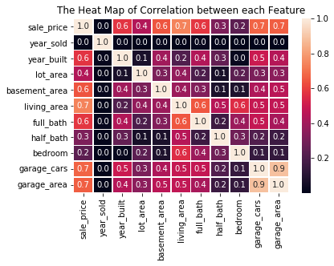

```python
obs.get_corr()
```

Here I will discuss the `year_sold` feature. From the heatmap of all numeric data, we can find a stange thing which is in the second row and second column, the correlations are all almost zero. It means the feature `year_sold` is irrelevant to not only `sale price` but also other features. So it is better to remove `year_sold` feature. The result also shows that remove `year_sold` can reduce the total *RMSE*.

I have tried PCA to reduce the dimension and extract more useful information to improve prediction. However, it is not useful for this data. only first component has a good relationship with `sale price`, the other components is very messy. using PCA even make prediction worse. So I didn't use PCA for this data. The PCA discussion can be seen in supplemental notebook.